# Markov_2

Mikolaj Biesaga

# Krok pierwszy - policzenie odstępów

Na samym początku oczywiście zacząłem od policzenia odstępów pomiędzy strzałami neuronów. Uznałem, że nie ma znaczenia liczba zer bo to jest funkcja czasu. Poza tym usunąłem też różnicę między pierwszym czasem i początkiem pomiaru bo nie ma ona żadnego znaczenia. Poniższe wykresy prezentują odstępy pomiędzy strzałami neuronów. Ostatni wykres to kross korelacja (niebieskie linie to oczywiście odchylenia, a czerwona to mediana).

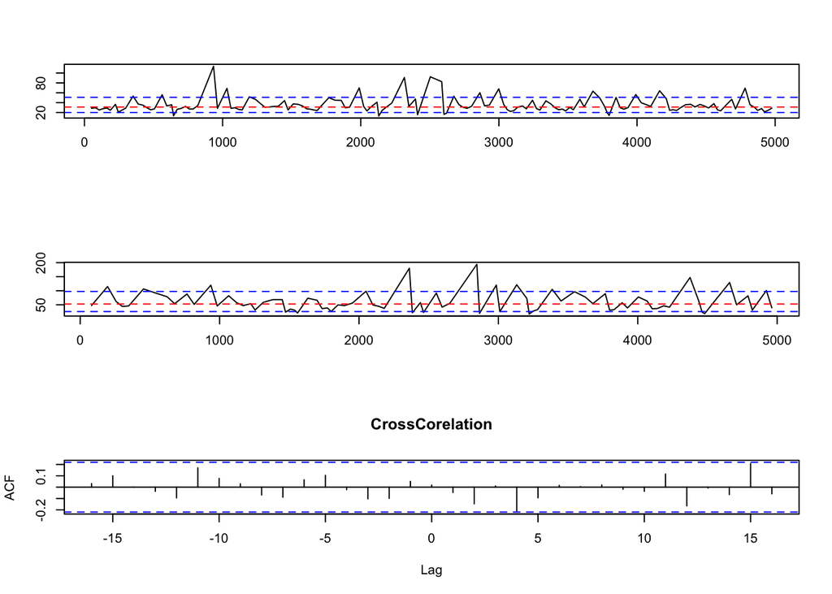

```
##
## 24.1999999999998             25.2 25.5999999999999 25.6999999999998
##                2                2                2                2
##             27.1             28.5             29.5 29.6000000000001
##                2                2                2                2
## 30.5999999999999 32.3000000000002             32.5             33.5
##                3                2                2                2
## 37.4000000000001 46.8000000000002
##                2                2
```

# Krok drugi - zbinowanie odstępów

Na razie zacząłem od tego, że zbinowałem je po 10 sekund (tzn. o ile czas mierzony był w sekundach, jeśli nie to po 10 jednostek czasu). Nie był to na pewno najgenialniejszy z moich pomysłów bo powstało strasznie dużo binów, co potwornie wydłużyło liczenie, ale na razie nie o tym. Poniżej poglądowe wykresy, histogramy (na niebiesko with heteregonity, na czerwono without) i boxploty. Zasadniczo zarówno na histogramach jak i boxplotach różnice w odstępach pomiedzy with heteregonity i without heteregonity są dość dobrze widoczne.

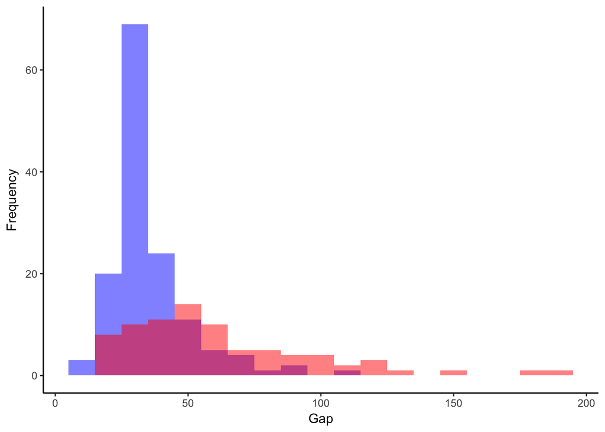

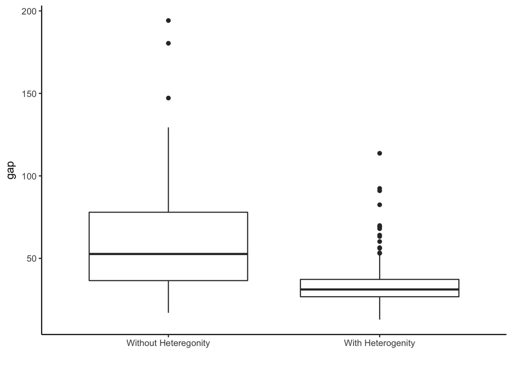

W zasadzie niezależnie od tego jak policzymy różnicę między tymi dwoma grupami, czy policzymy różnicę między średnimi czy też pomiędzy rangami to i tak wyjdzie istotna.

```
##
##  Kruskal-Wallis rank sum test
##
## data:  dane$gap by factor(dane$heterogenity)
## Kruskal-Wallis chi-squared = 42.765, df = 1, p-value = 6.172e-11
```

```
##
##  Welch Two Sample t-test
##
## data:  dane$gap by factor(dane$heterogenity)
## t = 6.2323, df = 95.985, p-value = 1.223e-08
## alternative hypothesis: true difference in means is not equal to 0
## 95 percent confidence interval:
##  17.86765 34.56878
## sample estimates:
## mean in group 0 mean in group 1
##        61.59750        35.37929
```

# Krok trzeci - policzenie historii

Na razie policzyłem to dla historii od 1 do 5 używając tego algorytmu o którym rozmawialiśmy ostatnio. Tak jak pisałem w mailu okazał się on daleki od idealnego co z resztą tutaj dobrze widać bo zgodność przewidywanego ciągu z orginalnym jest dość niska (pierwszy wynik to with heteregonity drugi to without heteregonity), tzn. prawie 3 razy wyższ w obu przypadkach niż losowa ale i tak bardzo niska.

```
## [1] 0.352518
```

```
## [1] 0.1518987
```

Powody tego są dwa. Jeden jest taki, że przy wielu binach ciągi powinny być dłuższe, tzn. tak jak w tym drugim przypadku (without heteregonity) mamy ciąg 80 elementowy, i 15 różnych odległości, przez co ten algorytm nie zdąża niczego się nauczyć zanim ciąg się skończy. Oczywiście w tym wypadku zwiększenie długości ciągów jest mniej lub bardziej niemożliwe więc trzeba zwiększyć biny, co oczywiście wiąże się ze stratą informacji. Im mniej binów tym lepiej, tzn. popróbuje z różnymi ilościami binów wtedy też szybkość powinna się zwiększyć bo na razie o ile liczenie tego pierwszego (with heteregonity) zajęła około 20 minut to tego drugiego (without heteregonity) półtorej godziny. Drugi powód jest taki, że ten algorytm dalej nie zachowuje się dokładnie tak jak bym chciał. Już mi się wydawało, że wszystko jest dobrze ale na tych nowych danych dalej to nie wygląda tak jak powinno. Wydaje mi się, że będę musiał napisać go na nowo, już nawet wiem jak ale to jednak trochę potrwa.

Poniżej są podstawowe wykresy. Na osi y jest historia, a na osi x odstępy pomiędzy strzałami neuronów. Ten pierwszy wykres jest dłuższy bo odstępów było 140 w tym pliku with heteregonity, podczas gdy dla without heteregonity 80. Na pierwszym wykresie widać, że niewykorzystywana jest historia 4, a na drugim historia 5.

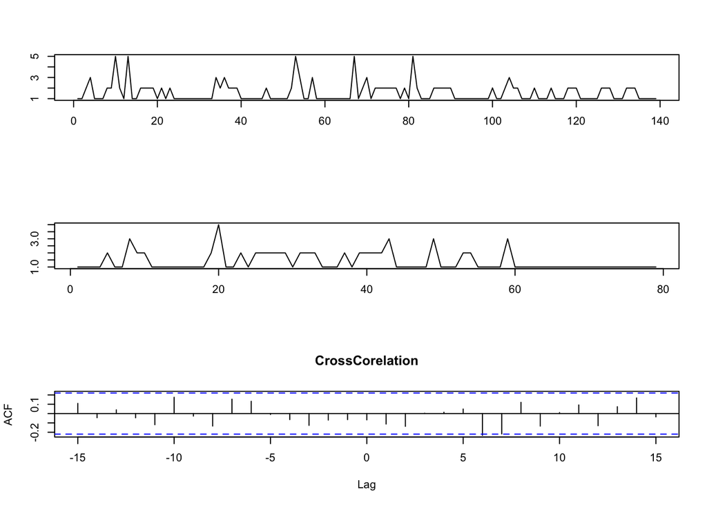

Poniżej rozkłady prawdopodobieństwa historii na podstawie, której przewidywane były ciągi. Widać, że w obu przypadkach przewidywanie na podstawie historii jeden, czyli na podstawie poprzedniego wyrazu było naczjęściej wykorzystywane. Szczerze mówiąc spodziewałem się, że te wykresy będą dużo ciekawsze…

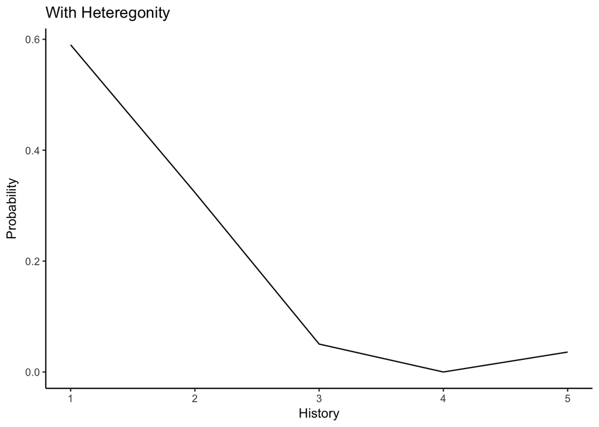

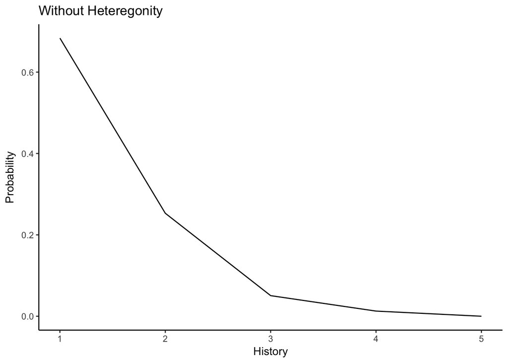

# Podsumowanie

Ogólnie w jakmiś stopniu zaskoczyły mnie te dane mimo że mnie uprzedzałeś. Wydawało mi się, że mój algorytm poradzi sobie z nimi bez problemu co jak widać okazało się dość złudnym założeniem. Myślę, że teraz najważniejsze jest zwiększenie prawdopodobieństwa przewidywania bo bez tego ani rusz. Ciężko coś powiedzieć na temat różnicy pomiędzy tymi dwoma ciągami (with heteregonity i without heteregonity) jeśli zgodność przewidywanego ciągu z oryginalnym jest na poziomi 15 %. Tak jak pisałem wyżej rozwiązania widzę dwa po pierwsze zwiększenie binów po drugie nowy algorytm. Mimo, że pierwsze wydaje się dość proste to jednak poczekałbym z jego implementacją, na nowy algorytm.